# NYCFlights: Arrival Delay Regression Model (Open Ended Variation)

Thuyen Nguyen

04/17/2017

# NYCFlights Model

Using the rectangular data that you created last week create a model for `arr_delay`. Follow a well defined process for creating a model as discussed in class or from one of the readings.

Break the process down into steps and create a codeblock for each step. - Use as many steps you feel as necessary - Concisely explain each step - Show all work

(You can start with the data that you created last week.)

## Setup Data

```r
library(readr)
library(data.table)
library(dplyr)
```

```r
library(ggplot2)
library(lubridate)
library(magrittr)

airports <- read_csv("~/Documents/CSX460/02-building-blocks/02-exercise-nycflights/data/airports.csv") %>% setDT
flights <- read_csv("~/Documents/CSX460/02-building-blocks/02-exercise-nycflights/data/flights.csv") %>% setDT
planes <- read_csv("~/Documents/CSX460/02-building-blocks/02-exercise-nycflights/data/planes.csv") %>% setDT
weather <- read_csv("~/Documents/CSX460/02-building-blocks/02-exercise-nycflights/data/weather.csv") %>% setDT
data_join <- flights %>%
  transform(dephour = floor(dep_time / 100)) %>%
  left_join(.,planes, by=c("tailnum" = "tailnum")) %>%
  left_join(.,airports,by=c("origin"="faa"))  %>%
  left_join(.,airports,by=c("dest"="faa")) %>%
  left_join(.,weather, by=c("origin"="origin","dephour"="hour","year.x"="year","month"="month","day"="day"))
head(data_join)
```

```
##   year.x month day dep_time sched_dep_time dep_delay arr_time
## 1   2013     1   1      517            515         2      830
## 2   2013     1   1      533            529         4      850
## 3   2013     1   1      542            540         2      923
## 4   2013     1   1      544            545        -1     1004
## 5   2013     1   1      554            600        -6      812
## 6   2013     1   1      554            558        -4      740
##   sched_arr_time arr_delay carrier flight tailnum origin dest air_time
## 1            819        11      UA   1545  N14228    EWR  IAH      227
## 2            830        20      UA   1714  N24211    LGA  IAH      227
## 3            850        33      AA   1141  N619AA    JFK  MIA      160
## 4           1022       -18      B6    725  N804JB    JFK  BQN      183
## 5            837       -25      DL    461  N668DN    LGA  ATL      116
## 6            728        12      UA   1696  N39463    EWR  ORD      150
##   distance hour minute         time_hour.x dephour year.y
```

[output cut: 41 more lines]

## Step 1

```r
fit <- lm(formula= arr_delay ~ +dep_delay +carrier, data=data_join)
summary(fit)
```

```
##
## Call:
## lm(formula = arr_delay ~ +dep_delay + carrier, data = data_join)
##
## Residuals:
##      Min       1Q   Median       3Q      Max
## -109.027  -10.999   -2.093    8.591  207.271
##
## Coefficients:
##               Estimate Std. Error  t value Pr(>|t|)
## (Intercept) -9.3708163  0.1356573  -69.077  < 2e-16 ***
## dep_delay    1.0189124  0.0007794 1307.306  < 2e-16 ***
## carrierAA    1.0039146  0.1677785    5.984 2.19e-09 ***
## carrierAS   -6.5010930  0.6805793   -9.552  < 2e-16 ***
## carrierB6    5.6159947  0.1551834   36.189  < 2e-16 ***
## carrierDL    1.6167608  0.1577618   10.248  < 2e-16 ***
## carrierEV    4.9531171  0.1562607   31.698  < 2e-16 ***
## carrierF9   10.7082945  0.6938445   15.433  < 2e-16 ***
## carrierFL   10.5288545  0.3429092   30.704  < 2e-16 ***
## carrierHA   -2.5376548  0.9698466   -2.617  0.00888 **
## carrierMQ    9.5026221  0.1756666   54.095  < 2e-16 ***
## carrierOO    8.4776090  3.3007309    2.568  0.01022 *
## carrierUA    0.6846510  0.1539787    4.446 8.73e-06 ***
## carrierUS    7.6848978  0.1850461   41.530  < 2e-16 ***
## carrierVX   -1.8626233  0.2826672   -6.589 4.42e-11 ***
## carrierWN    1.0242553  0.2107811    4.859 1.18e-06 ***
## carrierYV    5.6714818  0.7733433    7.334 2.24e-13 ***
## ---
## Signif. codes:  0 '***' 0.001 '**' 0.01 '*' 0.05 '.' 0.1 ' ' 1
##
## Residual standard error: 17.76 on 327329 degrees of freedom
##   (9430 observations deleted due to missingness)
## Multiple R-squared:  0.8417, Adjusted R-squared:  0.8417
## F-statistic: 1.088e+05 on 16 and 327329 DF,  p-value: < 2.2e-16
```

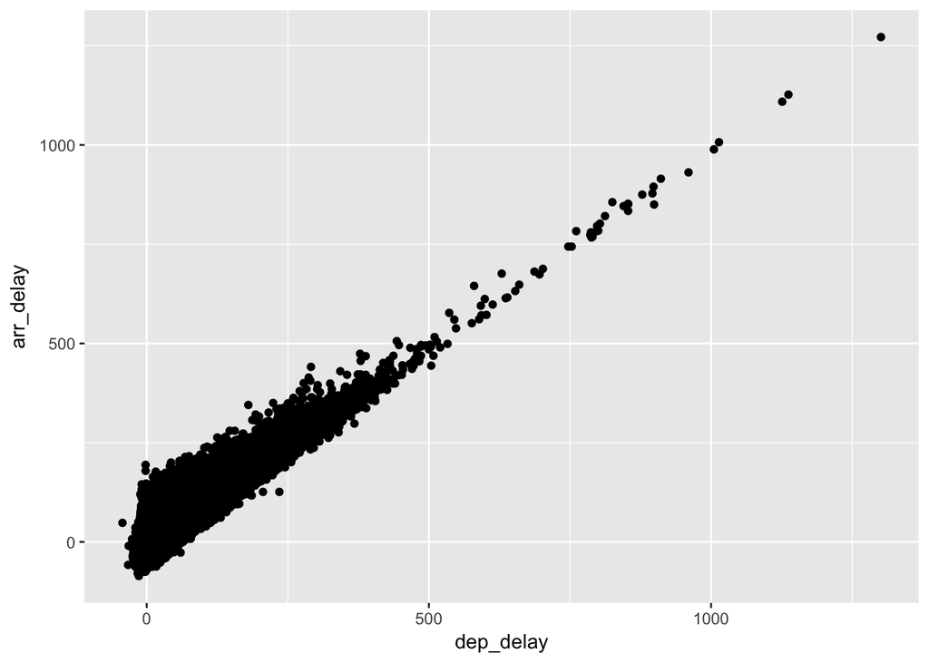

```r
ggplot(flights, aes(dep_delay, arr_delay)) +geom_point()
```